# Assignment_4

# Exercise 3

## Make a normal probability plot of sim_norm. Do all of the points fall on the line? How does this plot compare to the probability plot for the real data? (Since sim_norm is not a data frame, it can be put directly into the sample argument and the data argument can be dropped.)

```r
sim_norm <- rnorm(n = nrow(dairy_queen), mean = dqmean, sd = dqsd)
sim_norm
```

```
##  [1]  337.11667  169.67562  265.84329  295.99060   51.63293  417.68812
##  [7]  251.48065  322.63522  132.80237  404.82098  269.31568  354.22833
## [13]  -19.97419  231.42225  107.55406  270.40700  301.45740  375.95839
## [19]  288.41480  117.56646  524.71657  149.81713  202.26686  212.41018
## [25]  175.59007  614.80777  219.05603  467.69258  331.89379  747.97536
## [31]  122.77859  369.07107  245.80837  322.12927  357.01169  363.10974
## [37]  282.25802  301.06208  247.38547 -155.01396  117.65219  286.96962
```

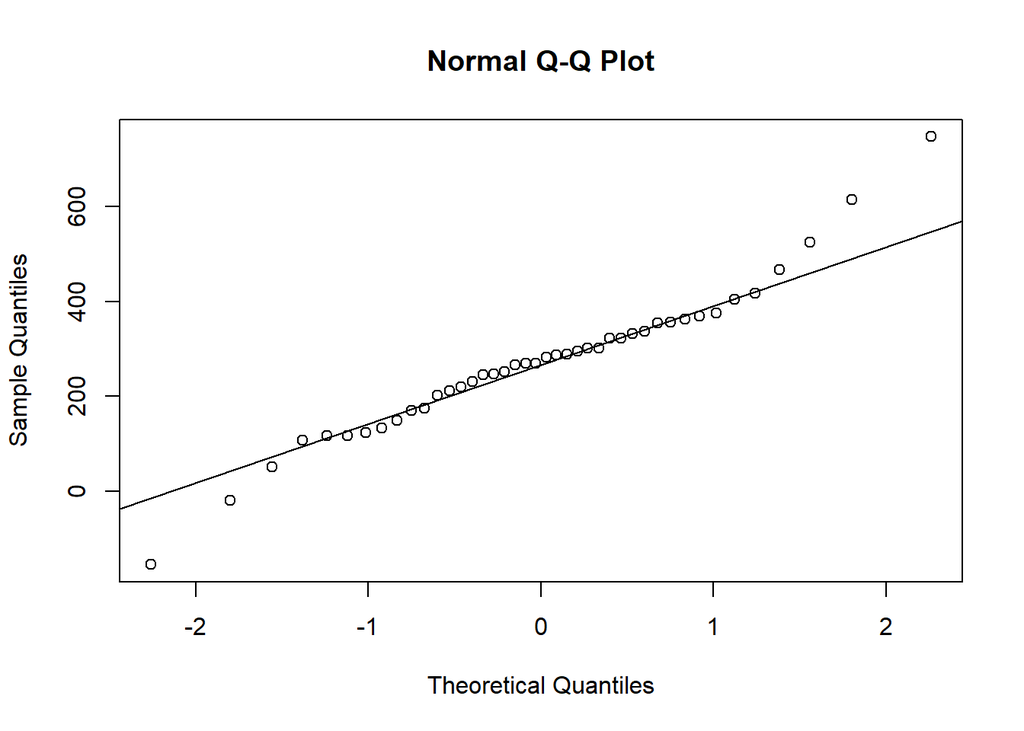

```r
qqnorm(sim_norm)
qqline(sim_norm)
```

Not all the points fall on the line as nothing is perfect! However, this is comparable to the data in the DQ set!

# Exercise 4

## Does the normal probability plot for the calories from fat look similar to the plots created for the simulated data? That is, do the plots provide evidence that the calories are nearly normal?

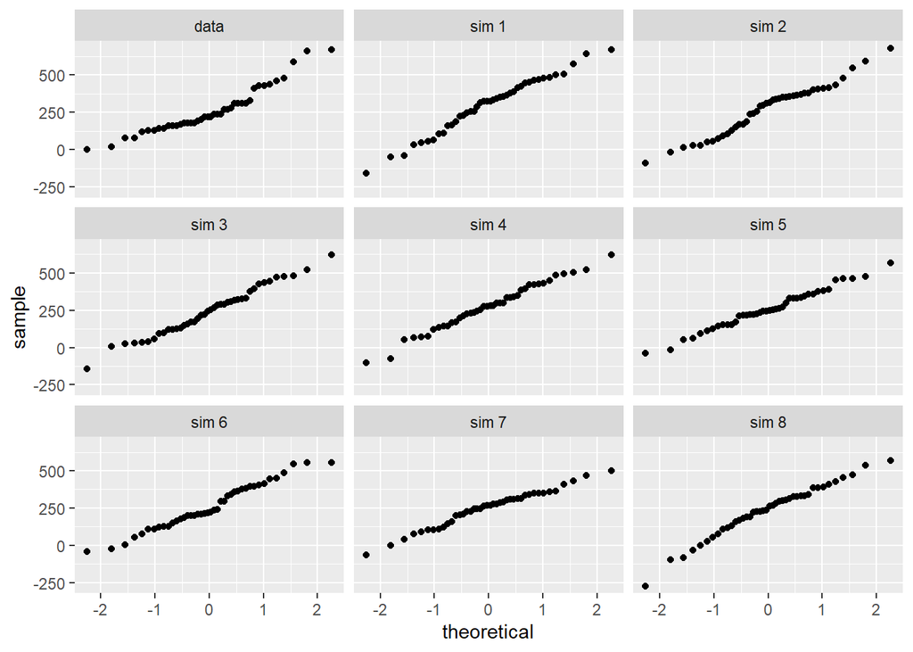

```r
qqnormsim(sample = cal_fat, data = dairy_queen)
```

Yes, the plots demonstrate a remarkable similarty to the data, indicating that calories are nearly normal.

# Exercise 5

## Using the same technique, determine whether or not the calories from McDonald’s menu appear to come from a normal distribution.

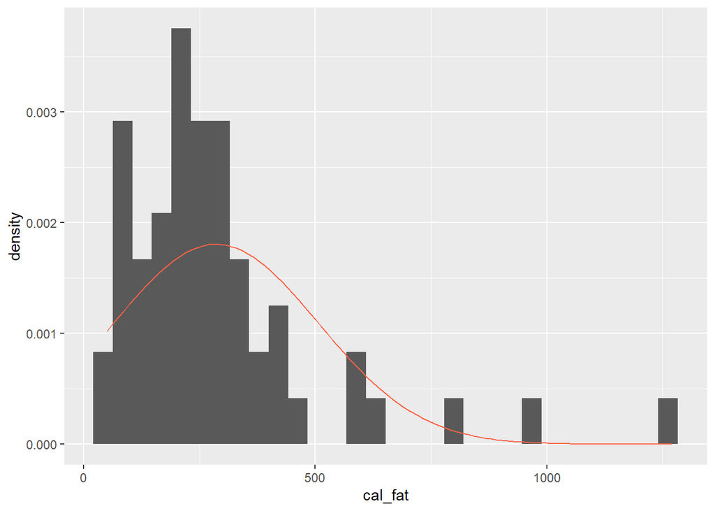

```r
mdmean_md <- mean(mcdonalds$cal_fat)
mdsd_md   <- sd(mcdonalds$cal_fat)
ggplot(data = mcdonalds, aes(x = cal_fat)) +
        geom_blank() +
        geom_histogram(aes(y = ..density..)) +
        stat_function(fun = dnorm, args = c(mean = mdmean_md, sd = mdsd_md), col = "tomato")
```

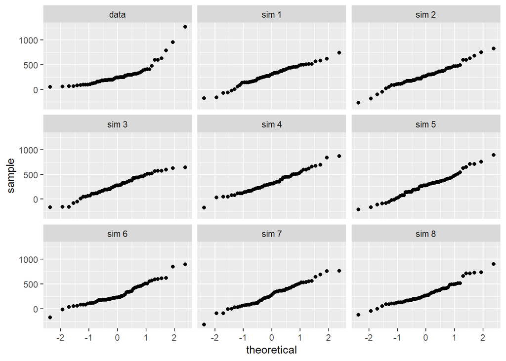

```r
qqnormsim(sample = cal_fat, data = mcdonalds)
```

# Exercise 6

## Write out two probability questions that you would like to answer about any of the restaurants in this dataset. Calculate those probabilities using both the theoretical normal distribution as well as the empirical distribution (four probabilities in all). Which one had a closer agreement between the two methods?

Question 1: How many items on the McDonald’s menu are under 500mg of salt?

```r
mdmean_md <- mean(mcdonalds$sodium)
mdsd_md   <- sd(mcdonalds$sodium)
pnorm(q = 500, mean = mdmean_md, sd = mdsd_md)
```

```
## [1] 0.1826921
```

```r
mcdonalds %>%
  filter(sodium < 500) %>%
  summarise(percent = n() / nrow(mcdonalds))
```

| percent |
| --- |
| 0.05263158 |

In terms of item selection, McDonalds has less items than expected with less than 500mg of sodium!

Question 2: How many items on the Dairy Queen Menu have more than 20g of sugar?

```r
dqmean_md <- mean(dairy_queen$sugar)
dqsd_md   <- sd(dairy_queen$sugar)
1-pnorm(q = 20, mean = dqmean_md, sd = dqsd_md)
```

```
## [1] 0.003318644
```

```r
mcdonalds %>%
  filter(sugar > 20) %>%
  summarise(percent = n() / nrow(dairy_queen))
```

| percent |
| --- |
| 0.07142857 |

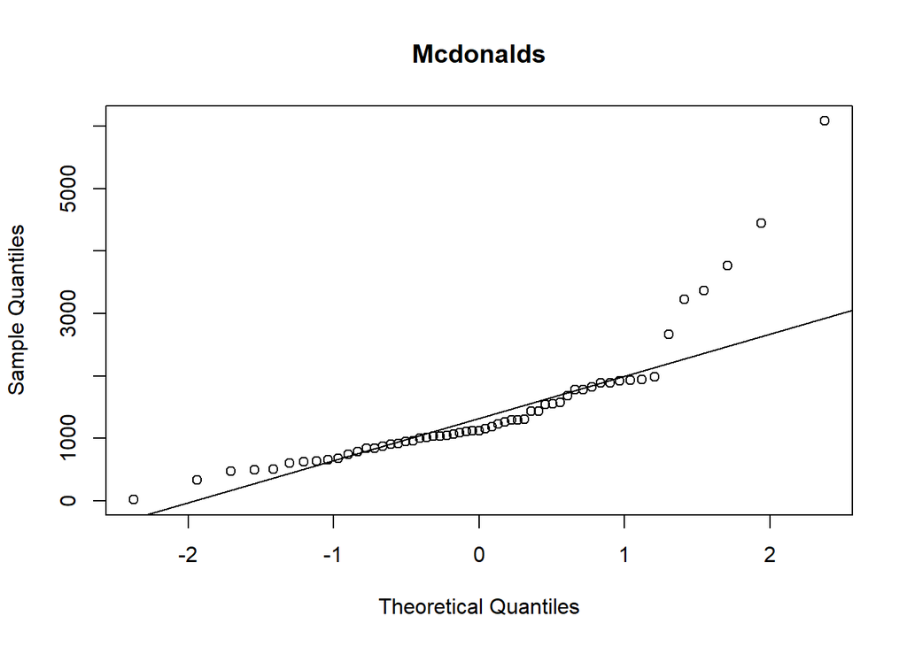

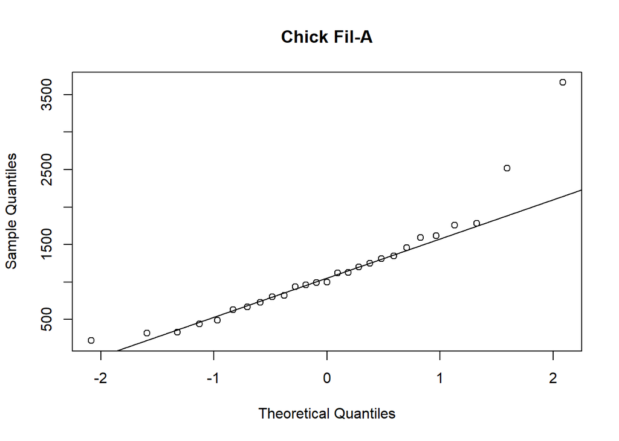

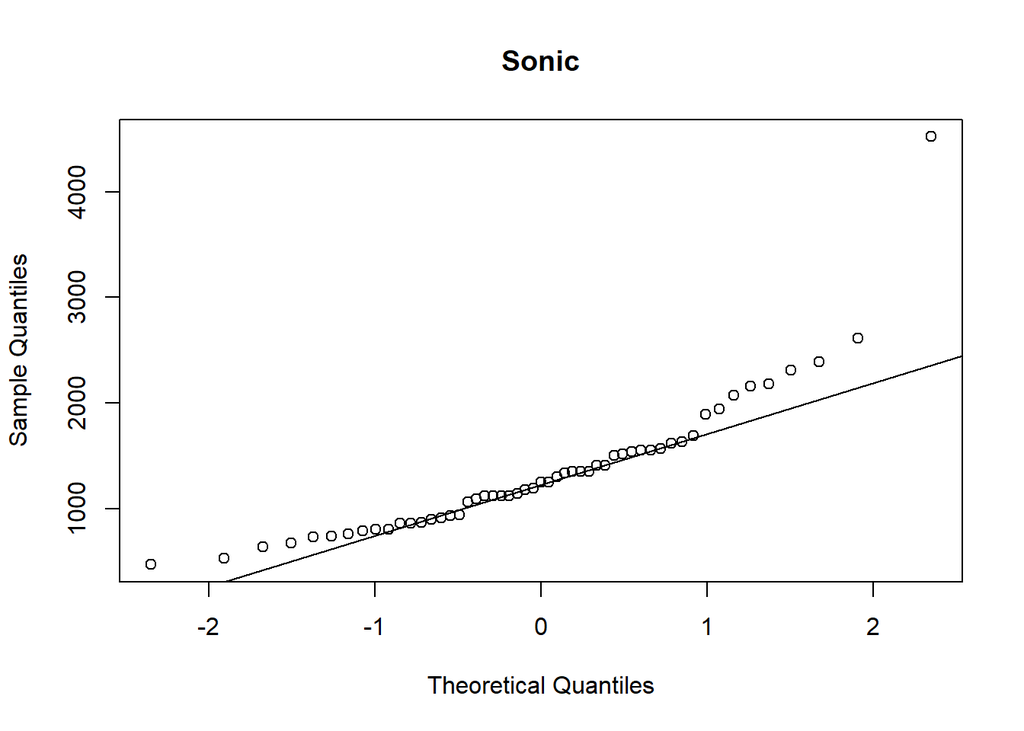

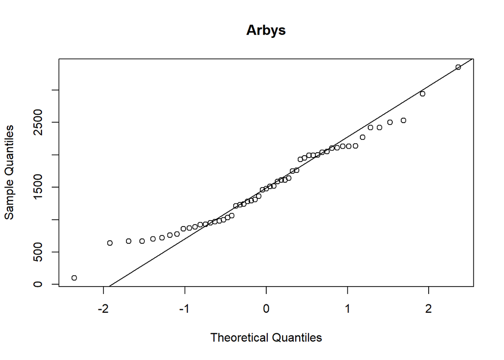

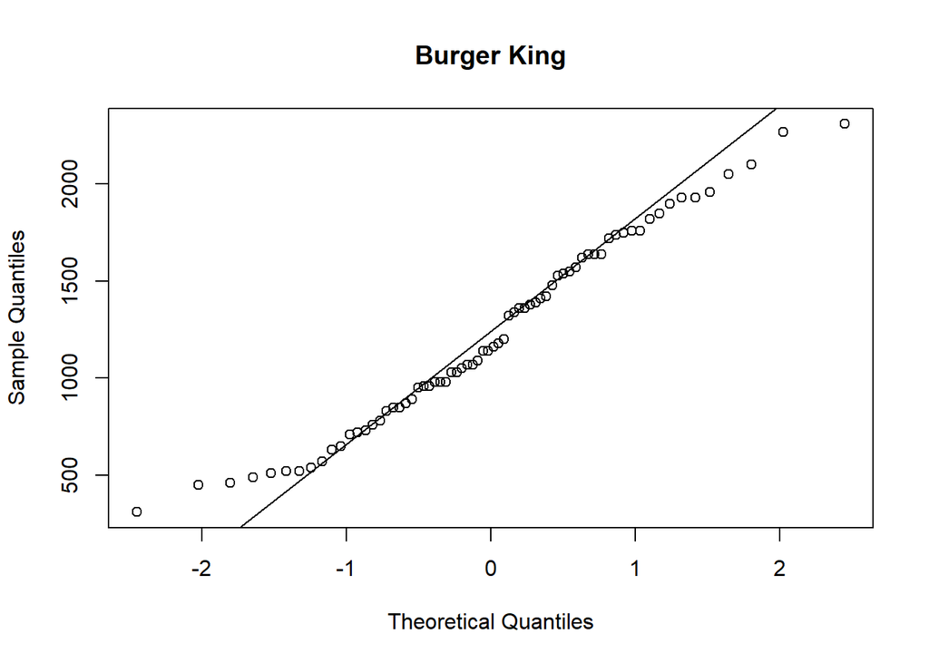

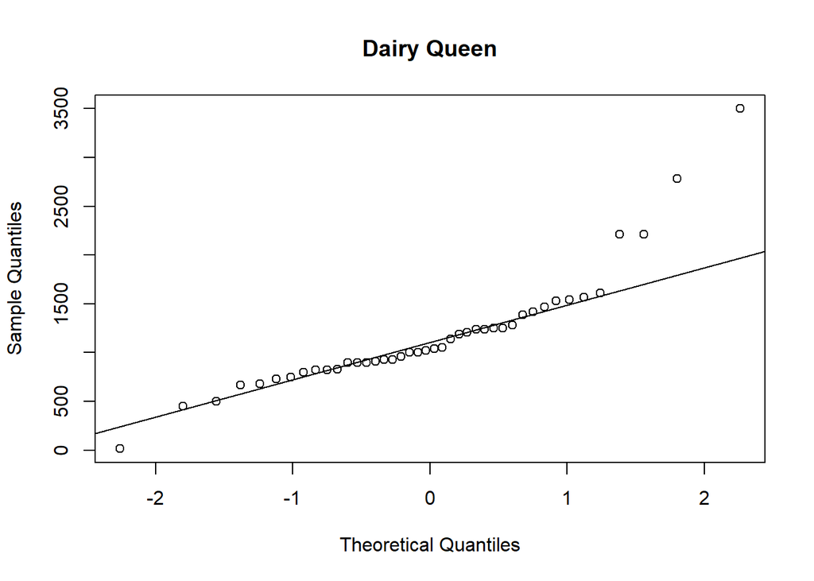

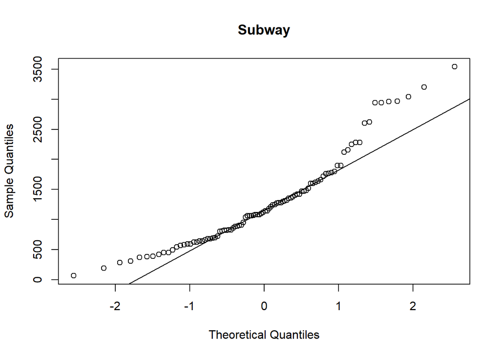

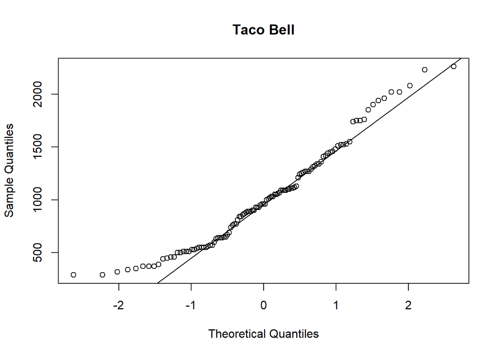

```r
for (ids in unique(fastfood$restaurant)){
  test <- fastfood %>%
    filter(restaurant == ids)
    qqnorm(test[test$restaurant == ids, c('sodium') ]$sodium, main = ids)
    qqline(test[test$restaurant == ids, c('sodium') ]$sodium)
}
```

Looking at the chart, Burger King is closest to normal.

# Exercise 8

## Note that some of the normal probability plots for sodium distributions seem to have a stepwise pattern. why do you think this might be the case?

Practically, the stepwise pattern is a result of creating discrete measurements rather than continous ones. For example is all measurements are rounded to the nearst digit would create a stepwise pattern.

# Exercise 9

## As you can see, normal probability plots can be used both to assess normality and visualize skewness. Make a normal probability plot for the total carbohydrates from a restaurant of your choice. Based on this normal probability plot, is this variable left skewed, symmetric, or right skewed? Use a histogram to confirm your findings.

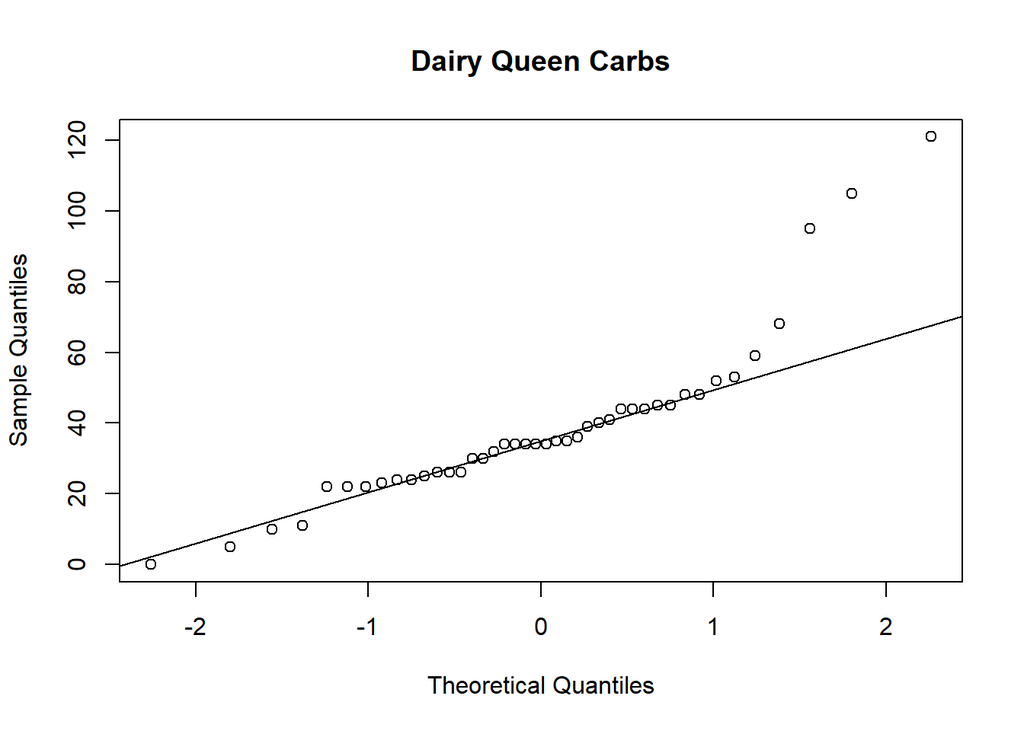

```r
#Normal plot for total carbohydrates from Dairy Queen
qqnorm(dairy_queen$total_carb, main = "Dairy Queen Carbs")
qqline(dairy_queen$total_carb)
```

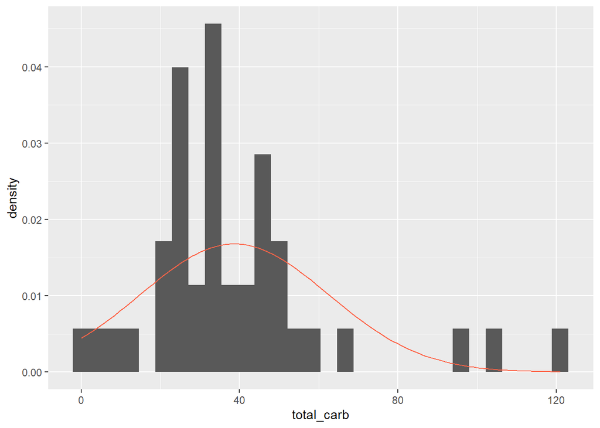

```r
dqmean <- mean(dairy_queen$total_carb)
dqsd   <- sd(dairy_queen$total_carb)
ggplot(data = dairy_queen, aes(x = total_carb)) +
        geom_blank() +
        geom_histogram(aes(y = ..density..)) +
        stat_function(fun = dnorm, args = c(mean = dqmean, sd = dqsd), col = "tomato")
```

Based on the diagram, the total_carb distrubution is right shifted, and is fairly normal.